# Prosper Loan Data

## Investigation Overview

- After finding that borrowr APR is set by Prosper score I then went on to find out what is a significant variable in settings this Prosper score and whether this relationships pertains within the two different homeowner stautus'.

## Dataset Overview

> (113937, 81)

Value counts:

- C 5649
- D 5153
- B 4389
- AA 3509
- HR 3508
- A 3315
- E 3289
- NC 141
- (with 84984 missing vlaues)
- ListingCreationDate (0 null) and ClosedDate (58848) (wrtong dytpes however)

### What is/are the main feature(s) of interest in your dataset?

> I am most interested in what features are best for predicting borrowersAPR. What is tricky about this is that a lot of our statistics are set by the borrowerAPR. For example Lender Yield is obviosuly staiscially dependent on borrower APR and we do not need statiscal evidence to understand this. Therefore I will be looking for variabls that are separate from this. My guess is that APR is set off propser rating and prosper rating is there to take into account catorgorical variables such as employment and income range etc.

### What features in the dataset do you think will help support your investigation into your feature(s) of interest?

> I expect that Prospers rating system will have the strongest correlation with the APR but it is then important to observe what predicts the Prospers rating to manfacture a strong understanding of this dataset.

```python
# import all packages and set plots to be embedded inline
import numpy as np
import pandas as pd
import matplotlib.pyplot as plt
import seaborn as sb

%matplotlib inline

# suppress warnings from final output
import warnings
warnings.simplefilter("ignore")
```

```python
base_color = sb.color_palette()[0]
```

```python
# load in the dataset into a pandas dataframe
df = pd.read_csv('mdf')
```

## Relationship between ProsperScore and income

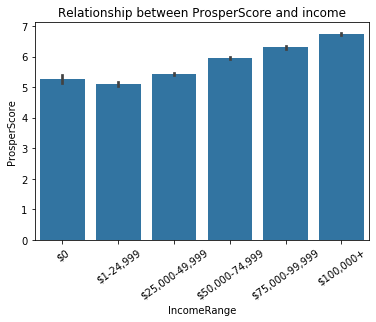

```python
plt.xticks(rotation=35)
sb.barplot(data=df, x='IncomeRange', y='ProsperScore', color=base_color,
           order=['$0', '$1-24,999', '$25,000-49,999',
                  '$50,000-74,999', '$75,000-99,999',
                  '$100,000+']).set_title('Relationship between ProsperScore and income');
```

## Relationship between ProsperScore and Debt

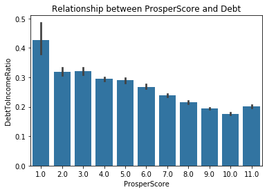

```python
sb.barplot(data=df, x='ProsperScore', y='DebtToIncomeRatio', color=base_color).set_title('Relationship between ProsperScore and Debt');
```

## Relationship between Prosper Score and Income Range - homeowner status

[figure not shown]

```python
df_homeowner = df[df['IsBorrowerHomeowner']== True]
df_nothomeowner = df[df['IsBorrowerHomeowner']== False]
plt.xticks(rotation=35)

sb.barplot(data=df_homeowner, x='IncomeRange', y='ProsperScore', color=base_color, order=['$0', '$1-24,999',
                                                                                             '$25,000-49,999',
                                                                                             '$50,000-74,999',
                                                                                             '$75,000-99,999',
                                                                                             '$100,000+']).set_title('Relationship between Prosper Score and Income Range - homeowner');
```

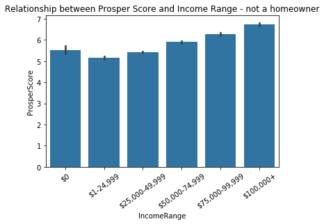

```python
plt.xticks(rotation=35)
sb.barplot(data=df_nothomeowner, x='IncomeRange', y='ProsperScore', color=base_color, order=['$0', '$1-24,999',
                                                                                             '$25,000-49,999',
                                                                                             '$50,000-74,999',
                                                                                             '$75,000-99,999',
                                                                                             '$100,000+']).set_title('Relationship between Prosper Score and Income Range - not a homeowner');
```